# Pragma Analysis

Author

Jakob & Kilian

# What Do I Do?

This document produces an analysis using LCA and Hierarchical Clustering with variable class/cluster numbers (k). It relies on data in the shape of sequence_data_for_kilian.csv with an aud.date column

The Results of the Models are visualized for easy interpretability

## LCA on binary treatment sequences

First, we import our preprocessed Data containing treatment series on a relative timescale

```r
library(here)
library(venneuler)
library(dendextend)
library(fs)
library(poLCA) # this package is a nightmare. It loads a select() function which overwrites tidyverse select() if tidyverse is loaded first or already attached to namespace
library(vegan)
library(timetk)
library(tidyverse)
library(here)
library(furrr)
library(vroom)
here::i_am("AnalyzePragmaDataQuartersAUD_NoRelTime.qmd")
```

```r
# set analysis parameters
analysis_vars = c("qwt", "inpat", "reha", "psych_short","psych_full", "medi", "bado") # set the variables which should be plotted and used within the analysis.
obs_period = "24m" # observational period
resol = "quarter" # time resolution for plotting purposes starting from aud date.
# possible vals: "day", "week", "month", "quarter", "halfyear", "year"
save = T # save transformed dataframe as cache in order to reexecute script faster
load_if_possible = T # if saved transformed df is found, load instead of compute
render = T # overrides console prompting for laod if possible in order to render document
classnum = 6# Which model should be used for subsequent analysis? (number equals classes of the desired model)
```

```r
getwd()
```

```
[1] "C:/Data.work/github/2024/PRAGMA_treatment-patterns"
```

```r
dat = read_rds(here("input","sequence_data_240515","4_data_AUD diagnosis and intervention sequences_2024-05-15.rds"))
# create an interv_id running within treatment type instead of across treatment types
dat = dat %>% left_join(dat %>%
  select(pragmaid, period, interv.type, interv_id) %>%
  drop_na() %>%
  group_by(pragmaid, period, interv.type) %>%
  mutate(interv_id_inner = 1:n()) %>%
  ungroup()
)
source(here("upsample_daily_utils.r")) # load up/downsampling and utility functions



# this takes a pretty long time (5minutes) on machine with 16 logical cores and 32gig ram. Significantly speeds up when all indivs who had no intervention are excluded from data before upsampling. # Results can be also precomputed via save and load_if_possible/ render

dat_qwt = get_treatment_series_at_resolution(dat,
                                             period = obs_period, # observation period
                                             resol = resol, # timestep resolution
                                             event = "aud", # event to start treatment series. currently does nothing (always set to aud)
                                             save = T, # save result when computed?
                                             load_if_possible = T, # load if same config exists in cache folder, prompts user in order to check if right file is laoded
                                             render = T, # forces load without prompting (ovverrides prompt and just chooses the most likely one)
                                             only_intervs = T) %>%
  filter(interv.any.allquarters == T) # only use cases where an intervention happened because LCA has problems fitting all the zero cases
```

Pivoting it into a wide format implicitly creates time sensitive dummy variables:

```r
# transform into wide format, such that the time is coded in dummy variables (qwt_t1, qwt_t2 ...)
dat_qwt_wide = dat_qwt %>%
  group_by(pragmaid, rel_time) %>%
  mutate(psych = any(psych_short, psych_full)) %>%
  ungroup() %>%
  select(pragmaid,
         rel_time,
         all_of(analysis_vars)
         ) %>%
  pivot_wider(id_cols = pragmaid,
              names_from = rel_time,
              values_from = all_of(analysis_vars)) %>%
  arrange(pragmaid)
#head(dat_qwt_wide)
```

For the poLCA package, data must occur in categorical levels, in increments from 1 to max level (in our case 2 since data is binary)

Now, create the formula and run LCA models on the dataset. We will try a 2-7 class solutions:

```
Model 1: llik = -7652.335 ... best llik = -7652.335
Model 2: llik = -7652.335 ... best llik = -7652.335
Model 3: llik = -7652.335 ... best llik = -7652.335
Model 4: llik = -7652.335 ... best llik = -7652.335
Model 5: llik = -7652.335 ... best llik = -7652.335
```

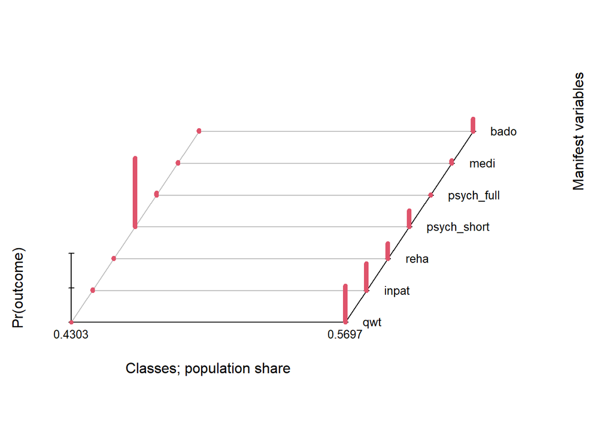

```
Conditional item response (column) probabilities,
 by outcome variable, for each class (row)

$qwt
           Pr(1)  Pr(2)
class 1:  0.9995 0.0005
class 2:  0.4699 0.5301

$inpat
           Pr(1)  Pr(2)
class 1:  0.9805 0.0195
class 2:  0.6045 0.3955

$reha
           Pr(1)  Pr(2)
class 1:  0.9846 0.0154
class 2:  0.7718 0.2282

$psych_short
           Pr(1)  Pr(2)
class 1:  0.0000 1.0000
class 2:  0.7614 0.2386

$psych_full
           Pr(1)  Pr(2)
class 1:  0.9628 0.0372
class 2:  0.9869 0.0131

$medi
           Pr(1)  Pr(2)
class 1:  0.9807 0.0193
class 2:  0.9541 0.0459

$bado
           Pr(1)  Pr(2)
class 1:  0.9756 0.0244
class 2:  0.8109 0.1891

Estimated class population shares
 0.4303 0.5697

Predicted class memberships (by modal posterior prob.)
 0.4457 0.5543

=========================================================
Fit for 2 latent classes:
=========================================================
number of observations: 2935
number of estimated parameters: 15
residual degrees of freedom: 112
maximum log-likelihood: -7652.335

AIC(2): 15334.67
BIC(2): 15424.44
G^2(2): 968.626 (Likelihood ratio/deviance statistic)
X^2(2): 1015.324 (Chi-square goodness of fit)
```

```r
f  = as.formula(paste0("cbind(",paste(analysis_vars, collapse = ","), ")~1" ))
# should equal:
# f = cbind(qwt, reha, medi, psych_short, psych_full, inpat, bado) ~ 1 # formula for LCA clustering

# poLCA needs variables to increment from 1 to max level
# 1 = No
# 2 = Yes
dat_qwt_num = dat_qwt %>%
  group_by(pragmaid) %>%
  summarize_at(analysis_vars, ~any(.x) + 1)


set.seed(341)
m2 = poLCA::poLCA(f, dat_qwt_num, nclass = 2, graph = T, maxiter = 100000, nrep = 5)
```

```
Model 1: llik = -7526.442 ... best llik = -7526.442
Model 2: llik = -7526.442 ... best llik = -7526.442
Model 3: llik = -7548.548 ... best llik = -7526.442
Model 4: llik = -7548.548 ... best llik = -7526.442
Model 5: llik = -7617.118 ... best llik = -7526.442
```

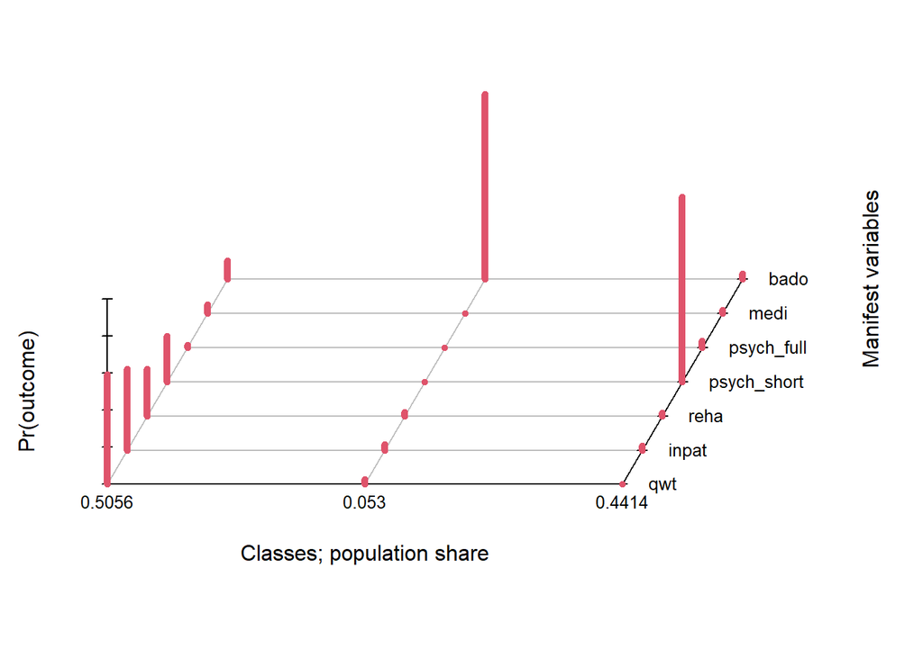

```
Conditional item response (column) probabilities,
 by outcome variable, for each class (row)

$qwt
           Pr(1)  Pr(2)
class 1:  0.4051 0.5949
class 2:  0.9727 0.0273
class 3:  1.0000 0.0000

$inpat
           Pr(1)  Pr(2)
class 1:  0.5616 0.4384
class 2:  0.9672 0.0328
class 3:  0.9765 0.0235

$reha
           Pr(1)  Pr(2)
class 1:  0.7472 0.2528
class 2:  0.9787 0.0213
class 3:  0.9826 0.0174

$psych_short
           Pr(1)  Pr(2)
class 1:  0.7531 0.2469
class 2:  1.0000 0.0000
class 3:  0.0000 1.0000

$psych_full
           Pr(1)  Pr(2)
class 1:  0.9860 0.0140
class 2:  1.0000 0.0000
class 3:  0.9628 0.0372

$medi
           Pr(1)  Pr(2)
class 1:  0.9493 0.0507
class 2:  1.0000 0.0000
class 3:  0.9801 0.0199

$bado
```

[output cut: 8 more lines]

```
Predicted class memberships (by modal posterior prob.)
 0.4865 0.0549 0.4586

=========================================================
Fit for 3 latent classes:
=========================================================
number of observations: 2935
number of estimated parameters: 23
residual degrees of freedom: 104
maximum log-likelihood: -7526.442

AIC(3): 15098.88
BIC(3): 15236.53
G^2(3): 716.8397 (Likelihood ratio/deviance statistic)
X^2(3): 729.8197 (Chi-square goodness of fit)
```

```r
m3 = poLCA::poLCA(f, dat_qwt_num, nclass = 3, graph = T, maxiter = 100000, nrep = 5)
```

```
Model 1: llik = -7382.304 ... best llik = -7382.304
Model 2: llik = -7507.927 ... best llik = -7382.304
Model 3: llik = -7374.32 ... best llik = -7374.32
Model 4: llik = -7406.018 ... best llik = -7374.32
Model 5: llik = -7496.54 ... best llik = -7374.32
```

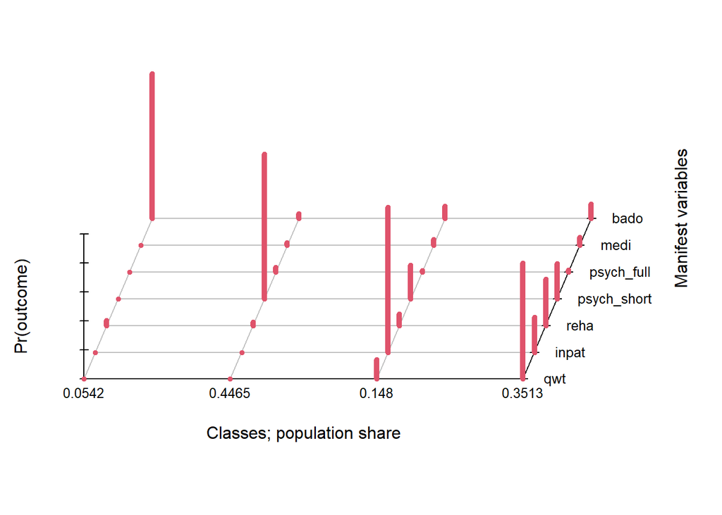

```
Conditional item response (column) probabilities,
 by outcome variable, for each class (row)

$qwt
           Pr(1)  Pr(2)
class 1:  1.0000 0.0000
class 2:  1.0000 0.0000
class 3:  0.8641 0.1359
class 4:  0.1970 0.8030

$inpat
           Pr(1)  Pr(2)
class 1:  1.0000 0.0000
class 2:  1.0000 0.0000
class 3:  0.0000 1.0000
class 4:  0.7559 0.2441

$reha
           Pr(1)  Pr(2)
class 1:  0.9655 0.0345
class 2:  0.9764 0.0236
class 3:  0.9203 0.0797
class 4:  0.6799 0.3201

$psych_short
           Pr(1)  Pr(2)
class 1:  1.0000 0.0000
class 2:  0.0000 1.0000
class 3:  0.7686 0.2314
class 4:  0.7567 0.2433

$psych_full
           Pr(1)  Pr(2)
class 1:  1.0000 0.0000
class 2:  0.9647 0.0353
class 3:  0.9878 0.0122
class 4:  0.9830 0.0170

$medi
           Pr(1)  Pr(2)
```

[output cut: 15 more lines]

```
Predicted class memberships (by modal posterior prob.)
 0.0579 0.4576 0.1448 0.3397

=========================================================
Fit for 4 latent classes:
=========================================================
number of observations: 2935
number of estimated parameters: 31
residual degrees of freedom: 96
maximum log-likelihood: -7374.32

AIC(4): 14810.64
BIC(4): 14996.16
G^2(4): 412.5942 (Likelihood ratio/deviance statistic)
X^2(4): 517.8294 (Chi-square goodness of fit)
```

```r
m4 = poLCA::poLCA(f, dat_qwt_num, nclass = 4, graph = T, maxiter = 100000, nrep = 5)
```

```
Model 1: llik = -7345.856 ... best llik = -7345.856
Model 2: llik = -7455.373 ... best llik = -7345.856
Model 3: llik = -7456.191 ... best llik = -7345.856
Model 4: llik = -7294.99 ... best llik = -7294.99
Model 5: llik = -7290.025 ... best llik = -7290.025
```

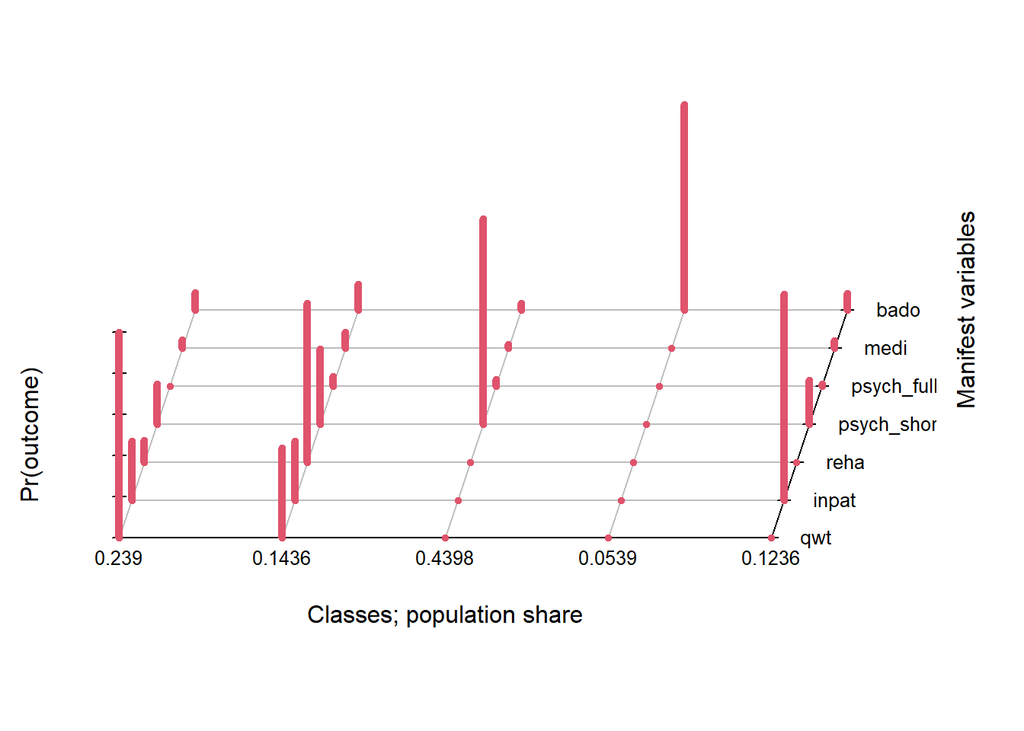

```
Conditional item response (column) probabilities,
 by outcome variable, for each class (row)

$qwt
           Pr(1)  Pr(2)
class 1:  0.0000 1.0000
class 2:  0.5599 0.4401
class 3:  1.0000 0.0000
class 4:  1.0000 0.0000
class 5:  1.0000 0.0000

$inpat
           Pr(1)  Pr(2)
class 1:  0.7113 0.2887
class 2:  0.7139 0.2861
class 3:  1.0000 0.0000
class 4:  1.0000 0.0000
class 5:  0.0000 1.0000

$reha
           Pr(1)  Pr(2)
class 1:  0.8926 0.1074
class 2:  0.2275 0.7725
class 3:  1.0000 0.0000
class 4:  1.0000 0.0000
class 5:  1.0000 0.0000

$psych_short
           Pr(1)  Pr(2)
class 1:  0.8028 0.1972
class 2:  0.6326 0.3674
class 3:  0.0000 1.0000
class 4:  1.0000 0.0000
class 5:  0.7850 0.2150

$psych_full
           Pr(1)  Pr(2)
class 1:  1.0000 0.0000
class 2:  0.9522 0.0478
class 3:  0.9658 0.0342
```

[output cut: 22 more lines]

```
Predicted class memberships (by modal posterior prob.)
 0.2273 0.1441 0.4446 0.0549 0.1291

=========================================================
Fit for 5 latent classes:
=========================================================
number of observations: 2935
number of estimated parameters: 39
residual degrees of freedom: 88
maximum log-likelihood: -7290.025

AIC(5): 14658.05
BIC(5): 14891.44
G^2(5): 244.0059 (Likelihood ratio/deviance statistic)
X^2(5): 344.4465 (Chi-square goodness of fit)
```

```r
m5 = poLCA::poLCA(f, dat_qwt_num, nclass = 5, graph = T, maxiter = 100000, nrep = 5)
```

```
Model 1: llik = -7232.976 ... best llik = -7232.976
Model 2: llik = -7233.008 ... best llik = -7232.976
Model 3: llik = -7232.976 ... best llik = -7232.976
Model 4: llik = -7232.976 ... best llik = -7232.976
Model 5: llik = -7233.008 ... best llik = -7232.976
```

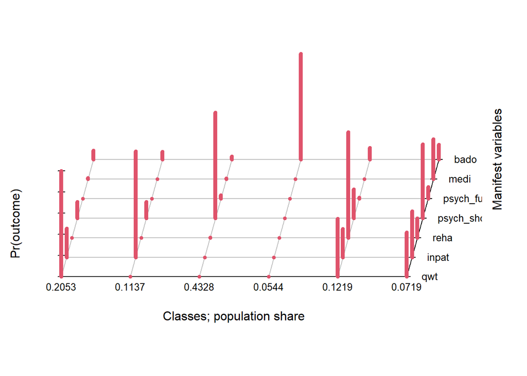

```
Conditional item response (column) probabilities,
 by outcome variable, for each class (row)

$qwt
           Pr(1)  Pr(2)
class 1:  0.0000 1.0000
class 2:  1.0000 0.0000
class 3:  1.0000 0.0000
class 4:  1.0000 0.0000
class 5:  0.4516 0.5484
class 6:  0.5812 0.4188

$inpat
           Pr(1)  Pr(2)
class 1:  0.7273 0.2727
class 2:  0.0000 1.0000
class 3:  1.0000 0.0000
class 4:  1.0000 0.0000
class 5:  0.7325 0.2675
class 6:  0.5630 0.4370

$reha
           Pr(1)  Pr(2)
class 1:  1.0000 0.0000
class 2:  1.0000 0.0000
class 3:  0.9965 0.0035
class 4:  1.0000 0.0000
class 5:  0.0000 1.0000
class 6:  0.8158 0.1842

$psych_short
           Pr(1)  Pr(2)
class 1:  0.8448 0.1552
class 2:  0.8432 0.1568
class 3:  0.0000 1.0000
class 4:  1.0000 0.0000
class 5:  0.7247 0.2753
class 6:  0.3016 0.6984

$psych_full
```

[output cut: 29 more lines]

```
Predicted class memberships (by modal posterior prob.)
 0.2191 0.122 0.4358 0.0549 0.1305 0.0378

=========================================================
Fit for 6 latent classes:
=========================================================
number of observations: 2935
number of estimated parameters: 47
residual degrees of freedom: 80
maximum log-likelihood: -7232.976

AIC(6): 14559.95
BIC(6): 14841.22
G^2(6): 129.9074 (Likelihood ratio/deviance statistic)
X^2(6): 144.4841 (Chi-square goodness of fit)
```

```r
m6 = poLCA::poLCA(f, dat_qwt_num, nclass = 6, graph = T, maxiter = 100000, nrep = 5)
```

```
Model 1: llik = -7208.417 ... best llik = -7208.417
Model 2: llik = -7234.719 ... best llik = -7208.417
Model 3: llik = -7219.168 ... best llik = -7208.417
Model 4: llik = -7208.495 ... best llik = -7208.417
Model 5: llik = -7209.025 ... best llik = -7208.417
```

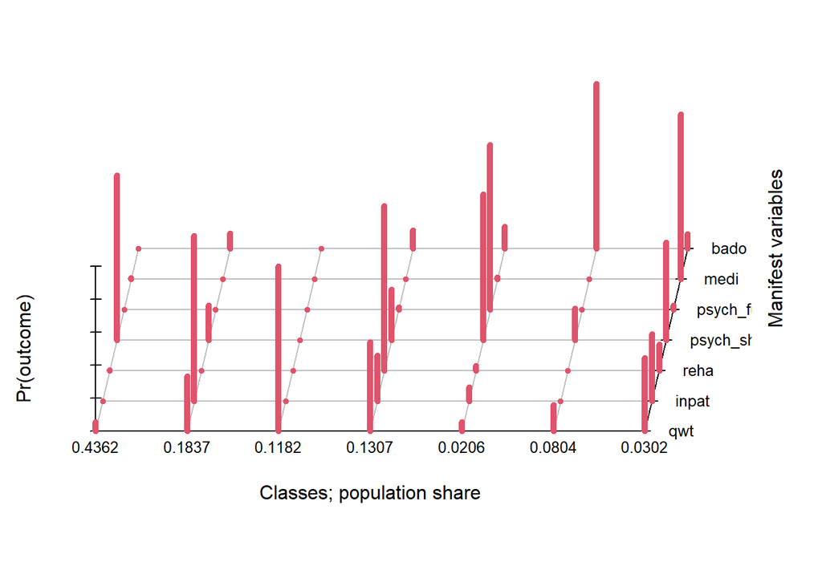

```
Conditional item response (column) probabilities,
 by outcome variable, for each class (row)

$qwt
           Pr(1)  Pr(2)
class 1:  0.9448 0.0552
class 2:  0.6643 0.3357
class 3:  0.0000 1.0000
class 4:  0.4590 0.5410
class 5:  0.9447 0.0553
class 6:  0.8390 0.1610
class 7:  0.5541 0.4459

$inpat
           Pr(1)  Pr(2)
class 1:  1.0000 0.0000
class 2:  0.0000 1.0000
class 3:  1.0000 0.0000
class 4:  0.7238 0.2762
class 5:  0.9175 0.0825
class 6:  1.0000 0.0000
class 7:  0.5957 0.4043

$reha
           Pr(1)  Pr(2)
class 1:  0.9988 0.0012
class 2:  1.0000 0.0000
class 3:  1.0000 0.0000
class 4:  0.0000 1.0000
class 5:  0.9702 0.0298
class 6:  1.0000 0.0000
class 7:  0.8421 0.1579

$psych_short
           Pr(1)  Pr(2)
class 1:  0.0000 1.0000
class 2:  0.7904 0.2096
class 3:  1.0000 0.0000
class 4:  0.6929 0.3071
class 5:  0.1149 0.8851
```

[output cut: 36 more lines]

```
Predicted class memberships (by modal posterior prob.)
 0.432 0.1836 0.1179 0.1312 0.0208 0.0804 0.0341

=========================================================
Fit for 7 latent classes:
=========================================================
number of observations: 2935
number of estimated parameters: 55
residual degrees of freedom: 72
maximum log-likelihood: -7208.417

AIC(7): 14526.83
BIC(7): 14855.98
G^2(7): 80.78872 (Likelihood ratio/deviance statistic)
X^2(7): 123.2628 (Chi-square goodness of fit)
```

```r
m7 = poLCA::poLCA(f, dat_qwt_num, nclass = 7, graph = T, maxiter = 100000, nrep = 5)
```

```r
# choose the n class solution for both models, the lca and the hierarchical clusterings
dat_qwt_num$predclass = eval(parse(text = paste0("m", classnum, "$predclass")))
dat_qwt_num %>%
  select(pragmaid, predclass) %>%
  write_csv(here("output", "sequence_data_24m_monthly_lca_results.csv"))
```

## Visualize LCA results without 3D

Take a look at the proportion of individuals using a service over time, for the different clusters identified by the lca. This corresponds somewhat to binary “typical” group trajectories.

Looking at the variables from a group perspective results in the following plot:

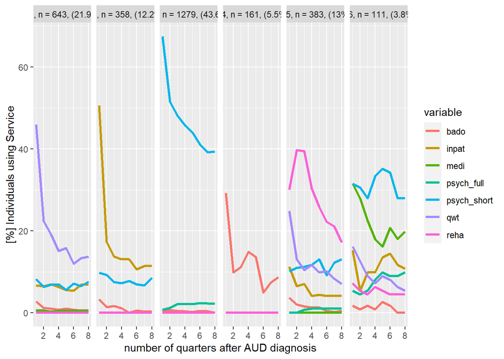

```r
dat_qwt_num %>%
  select(pragmaid, predclass) %>%
  left_join(dat_qwt) %>%
  group_by(predclass, rel_time) %>%
  summarize_at(all_of(analysis_vars), ~ sum(.x)/length(.x), ) %>%
  pivot_longer(cols = all_of(analysis_vars),
               names_to = "variable",
               values_to = "value") %>%
  ggplot(aes(x = rel_time, y = value*100, col = variable)) +
  geom_line(linewidth = 1.2) +
  facet_grid(.~predclass, scales = "free_y",labeller = as_labeller(label_fn(dat_qwt_num))) +
  labs(x = "number of quarters after AUD diagnosis",
       y = "[%] Individuals using Service")

ggsave(paste0("output/","figures/","fig_classes_lineplot_class6.png"), width = 10, height = 6)
```

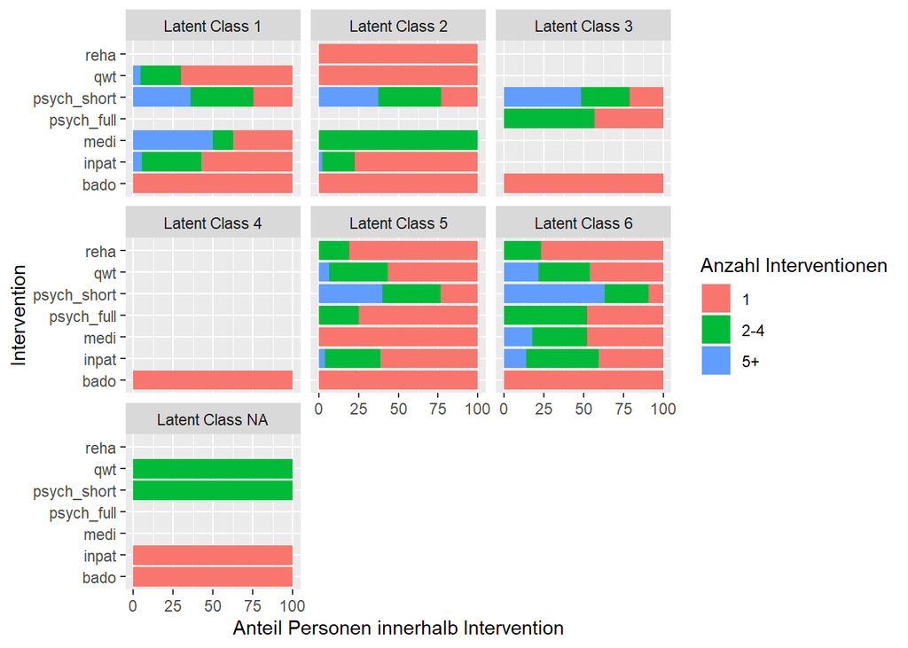

```r
#TODO: Explore mosaic plots{
#TODO: Zeitliche auflösung der zeitlichen Kreuztabellen durch Variablen ersetzen -
# TODO: Reha-qwt zusammenhang "Nicht fälle"! mit berücksichtigen als Spalte/Zeile
#TODO: Quarter Annahme raus nehmen und behandlungen durch tatsächliche interventions IDs ersetzen
#TODO: BLRT und Entropy berechnen!
# TODO add 2-4 and 5+ group into multiple interv chart


dat_pred = dat_qwt_num %>%
  select(pragmaid, predclass) %>%
  right_join(dat %>%
              filter(period == obs_period,
                     !is.na(interv_id_inner),
                     interv.any ==T)
             )
get_categorical_interv_num = function(num_intervs){
  if(num_intervs == 1) return("1")
  if(num_intervs > 1 & num_intervs <= 4) return("2-4")
  if(num_intervs > 4) return("5+")
}
get_categorical_interv = Vectorize(get_categorical_interv_num)

dat_pred %>%
  group_by(predclass) %>%
  mutate(n_class = n_distinct(pragmaid)) %>%
  ungroup() %>%
  group_by(pragmaid, predclass, interv.type) %>%
  mutate(num_intervs = n(), more_than_one_interv = get_categorical_interv(num_intervs)) %>%
  group_by(predclass, interv.type) %>%
  mutate(n_had_interv = n_distinct(pragmaid)) %>%
  group_by(predclass, interv.type, more_than_one_interv) %>%
  summarize(n = n_distinct(pragmaid), frac = n/mean(n_had_interv)) %>%
  ggplot(aes(x = interv.type, y = frac * 100)) +
  geom_col(aes(fill = more_than_one_interv)) +
  facet_wrap(~paste("Latent Class", predclass)) +
 # theme(axis.text.x = element_text(angle = 90, hjust = 1)) +
  labs(x = "Intervention", y = "Anteil Personen innerhalb Intervention", fill = "Anzahl Interventionen") +
  coord_flip()
```

```r
ggsave(paste0("output/","figures/","fig_classes_barplot.png"), width = 10, height = 6)
```

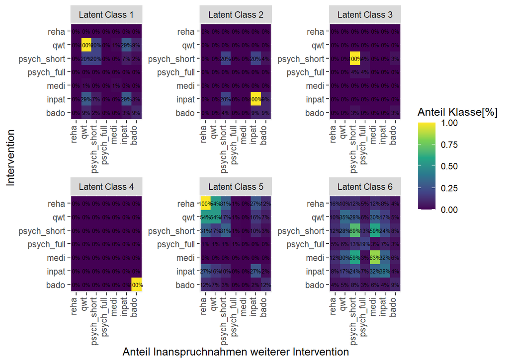

```r
dat_pred2 = dat_pred %>% select(pragmaid, predclass) %>% distinct() %>%  right_join(dat_qwt %>%
  group_by(pragmaid) %>%
  summarize_at(analysis_vars, ~any(.x)))
# helper function
get_overlap = function(dat,
                       cls,
                       var1,
                       var2,
                       perspective = c("class", "intervention")){


  perspective = match.arg(perspective)
  if(perspective == "class"){
  overlaps = dat %>%
    ungroup() %>%
    filter(predclass == cls) %>%
    select(pragmaid, all_of(c(var1,var2))) %>%
    group_by(pragmaid) %>%
    summarize(overlap = all(pick(var1),  pick(var2)))
  }
  else{
    dat = dat[c(dat[var1] == TRUE), ]
    overlaps = dat %>%
    ungroup() %>%
    filter(predclass == cls) %>%
    select(pragmaid, all_of(c(var1,var2))) %>%
    group_by(pragmaid) %>%
    summarize(overlap = all(pick(var1),  pick(var2)))
  }

  overlap = sum(overlaps$overlap)/nrow(overlaps)

  # res = data.frame(var = var1, val = overlap)
  # names(res)[2] = var2
  return(overlap)
}
# helper function end


get_inter_variable_overlaps = function(dat,
                                       cls,
                                       analysis_vars,
                                       perspective =  c("class", "intervention")){

perspective = match.arg(perspective)


resresres = data.frame()
for(v1 in analysis_vars){
  resres = data.frame(var = v1)

  for(v2 in analysis_vars){
    res = data.frame(val = get_overlap(dat,
                                       cls,
                                       v1,
                                       v2,
                                       perspective = perspective))
    names(res) = v2
    resres = cbind(resres, res)
  }

  resresres = rbind(resresres, resres)
}
resresres$predclass = cls
return(resresres)
}





overlaps_class_persp = map_dfr(1:classnum,
                               ~ get_inter_variable_overlaps(
                                            dat_pred2,
                                            cls =.x,
                                            analysis_vars,
                                            perspective = "class"))
overlaps_interv_persp = map_dfr(1:classnum,
                                ~ get_inter_variable_overlaps(
                                            dat_pred2,
                                            cls =.x,
                                            analysis_vars,
                                            perspective = "intervention"))

# TODO: Make the same for all without class

overlaps_class_persp %>%
  pivot_longer(cols = all_of(analysis_vars),
               names_to = "var2",
               values_to = "val") %>%
  mutate(var = as.factor(var), var2 = as.factor(var2)) %>%
  ggplot(aes(x = reorder(var, desc(var)), y = var2, fill = val)) +
  geom_tile() +
  facet_wrap(~paste0("Latent Class ", predclass), scales = "free") +
  geom_text(aes(label = paste0(round(val * 100, 0), "%")), size = 2) +
  scale_fill_viridis_c() +
  theme(axis.text.x = element_text(angle = 90, hjust = 1, vjust = 0)) +
  scale_x_discrete(limits = rev(levels(var))) +
  labs(x = "Anteil Inanspruchnahmen weiterer Intervention",
       y = "Intervention",
       fill = "Anteil Klasse[%]")
```

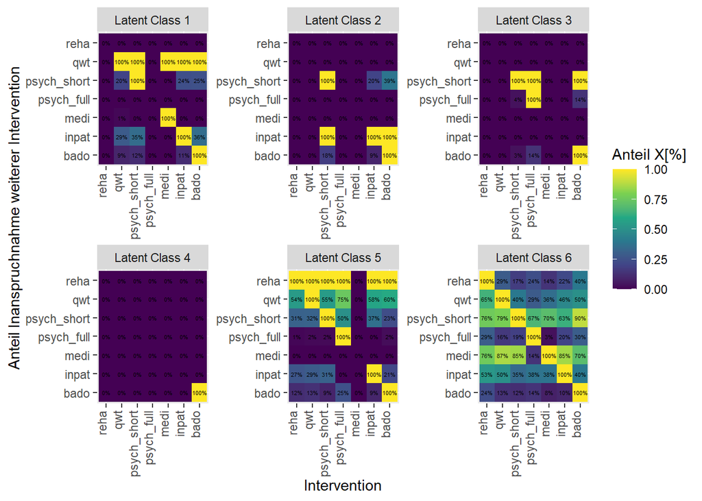

```r
# TODO: Add a column where the absolute percantage of class who did intervention y is displayed
overlaps_interv_persp %>%
  pivot_longer(cols = all_of(analysis_vars),
               names_to = "var2",
               values_to = "val") %>%
    mutate(var = as.factor(var), var2 = as.factor(var2),
           val = ifelse(is.nan(val), 0, val)) %>%
  ggplot(aes(x = reorder(var, desc(var)), y = var2, fill = val)) +
  geom_tile() +
  facet_wrap(~paste0("Latent Class ", predclass), scales = "free") +
  geom_text(aes(label = paste0(round(val * 100, 0), "%")), size = 1.5) +
  scale_fill_viridis_c() +
  theme(axis.text.x = element_text(angle = 90, hjust = 1, vjust = 0)) +
  scale_x_discrete(limits = rev(levels(var))) +
  labs(x = "Intervention",
       y = "Anteil Inanspruchnahme weiterer Intervention",
       fill = "Anteil X[%]")
```

We can display the same information with a Heatmap

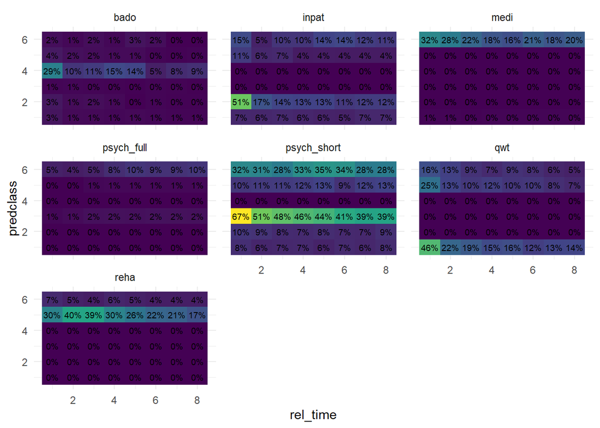

```r
# create a heatmap of the binary data used in the LCA
dat_qwt_num %>%
  select(pragmaid, predclass) %>%
  left_join(dat_qwt) %>%
  group_by(predclass, rel_time) %>%
  summarize_at(all_of(analysis_vars), ~ round(sum(.x)/length(.x), 3)*100, ) %>%
  pivot_longer(cols = all_of(analysis_vars),
               names_to = "variable",
               values_to = "value") %>%
  ggplot(aes(x = rel_time, y = predclass, fill = value)) +
  geom_tile(show.legend = F) +
  geom_text(aes(label = paste0(round(value, 0),"%")), size = 2.5) +
  theme_minimal() +
  scale_fill_viridis_c() +
  facet_wrap(~variable)
```

## Hierarchical Clustering via Jaccard (dis)similarity

In order to cluster the Data in a hierarchical structure, we construct jaccard dissimilarity (distance) matrices, which we can feed into the hclust function.

```r
# we can use the vegan package to get jaccard dissimilarity metric.
# or the builtin dist() function.




dat_qwt_sum = dat_qwt %>%
  group_by(pragmaid) %>%
  summarize(across(analysis_vars, ~any(.x)))
dist1 = dist(dat_qwt_sum %>% dplyr::select(all_of(analysis_vars)), method = "binary")
#identical
dist2 = vegdist(dat_qwt_sum %>% dplyr::select(all_of(analysis_vars)), method = "jaccard", binary = TRUE)
```

Now we can apply some different hierarchical clustering methods and visualize the results via dendrograms.

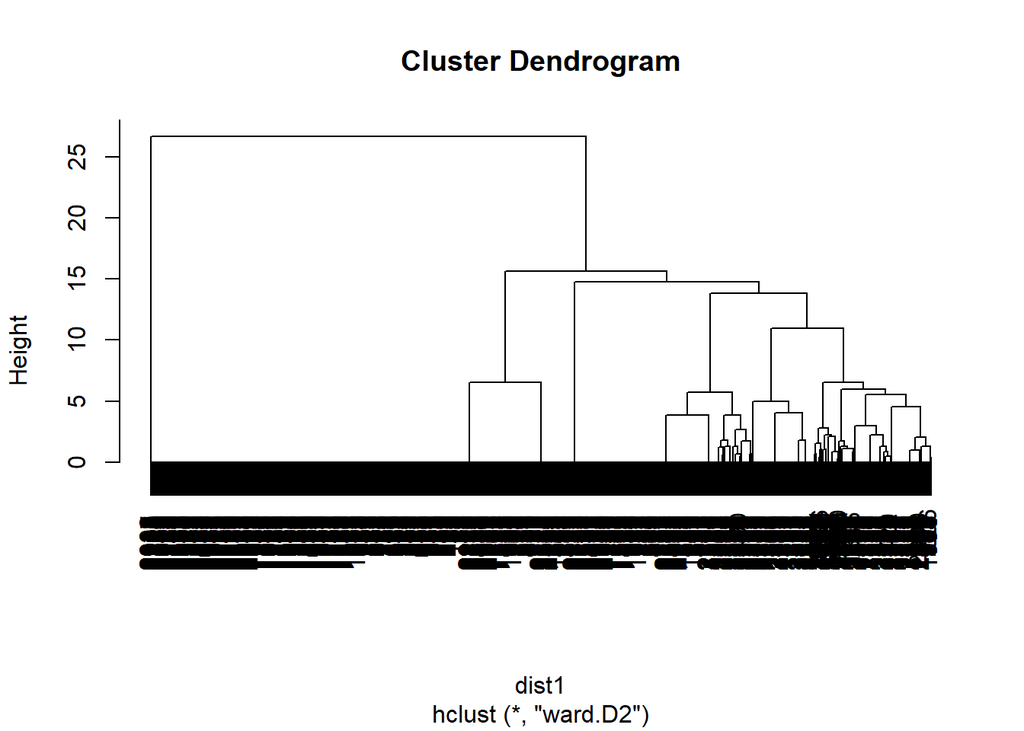

```r
c1 = hclust(dist1, method = "ward.D2")
plot(c1)
```

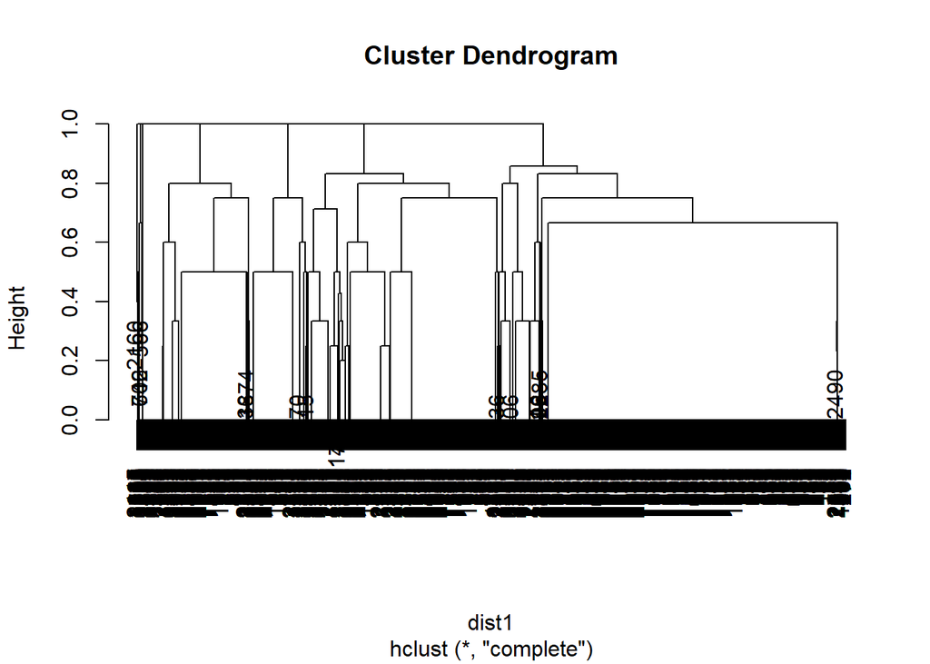

```r
#c2 = hclust(dist2, method = "average") # doesnt work when there are rows with FALSE only
#plot(c2)

c3 = hclust(dist1, method = "complete")
plot(c3)
```

I Liked the clusters in Method ward.D2 (c1) the best and will continue the analysis with these clusters. In order to maintain comparability with our lca results, I will remain at a 6 class solution.

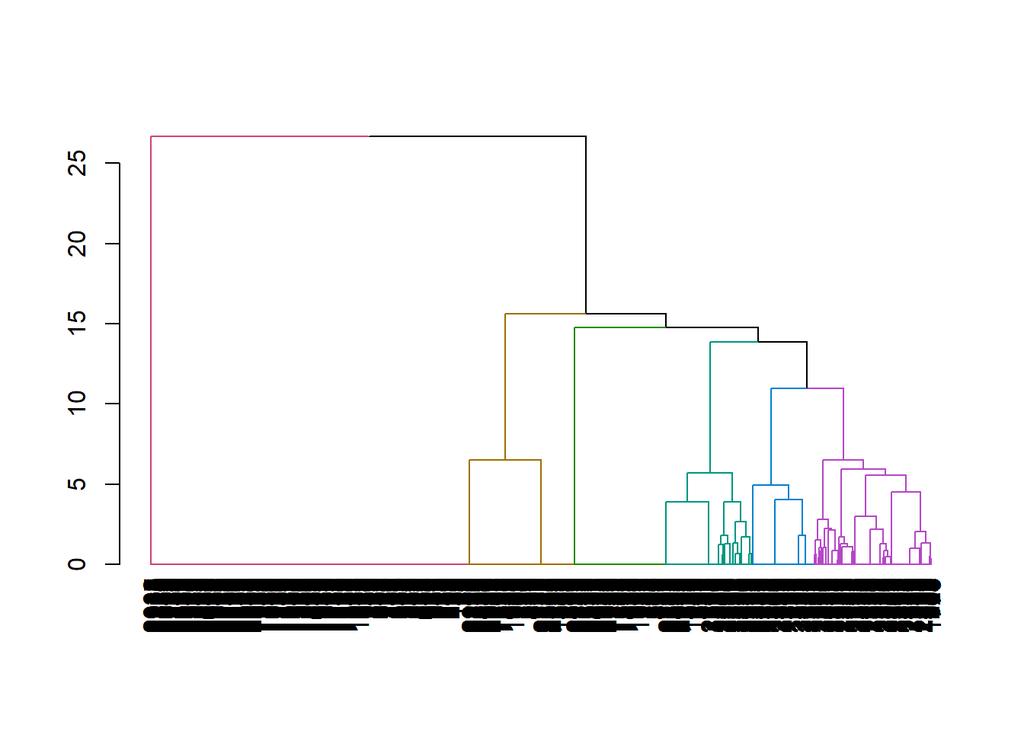

```r
dend_c1 = as.dendrogram(c1)
col_dend_c1 = color_branches(dend_c1, k = length(unique(dat_qwt_num$predclass)))
plot(col_dend_c1)
```

```r
cuts = cutree(c1, k= length(unique(dat_qwt_num$predclass)))
```

Now we can look at the proportion of individuals using a service over time, for the different clusters identified by the hierarchical clustering. This corresponds somewhat to binary “typical” group trajectories.

```r
frac = data.frame(clust = cuts %>% as.factor()) %>%
  group_by(clust) %>%
  summarize(n=n()) %>%
  mutate(frac = str_c(round(n/sum(n),3)*100, "%"))

frac %>%
  knitr::kable()
```

| clust | n | frac |
| --- | --- | --- |
| 1 | 1198 | 40.8% |
| 2 | 439 | 15% |
| 3 | 232 | 7.9% |
| 4 | 327 | 11.1% |
| 5 | 346 | 11.8% |
| 6 | 393 | 13.4% |

Swapping the variables with the clusters results in:

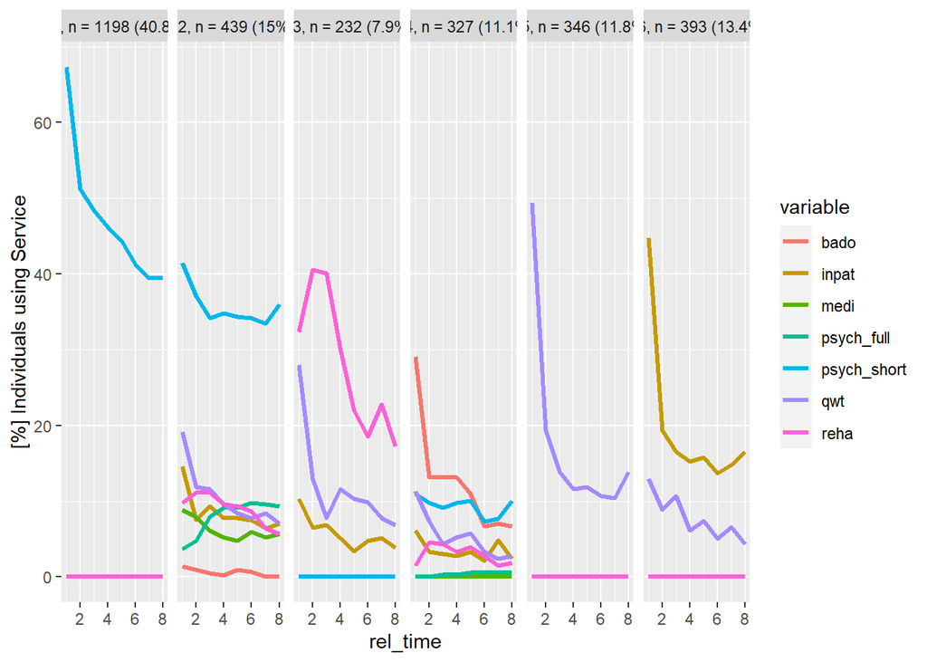

```r
label_fn2 = function(dat){

frac = data.frame(pragmaid = dat$pragmaid, cluster = dat$cluster %>% as.factor()) %>%
  group_by(cluster) %>%
  summarize(n=n_distinct(pragmaid)) %>%
  mutate(frac = str_c(round(n/sum(n),3)*100, "%"),
         predclass = as.integer(cluster))
  #print(frac)
  res = c()
  for(i in 1:nrow(frac)){
  res[i] = paste0("C" ,
                  frac[i, ]$cluster,
                  ", n = ",
                  frac[i, ]$n,
                  " (",
                  frac[i, ]$frac,
                  ")"
  )

  }
  names(res) = frac %>% select(predclass) %>% pull()
  return(res)
}

dat_qwt_wide %>%
  select(pragmaid, cluster) %>%
  left_join(dat_qwt) %>%
  group_by(cluster, rel_time) %>%
  summarize_at(all_of(analysis_vars), ~ sum(.x)/length(.x), ) %>%
  pivot_longer(cols = all_of(analysis_vars),
               names_to = "variable",
               values_to = "value") %>%
  ggplot(aes(x = rel_time, y = value*100, col = variable)) +
  geom_line(linewidth = 1.2) +
  facet_grid(.~cluster, scales = "free_y", labeller = as_labeller(label_fn2(dat_qwt_wide))) +
  labs(y = "[%] Individuals using Service")
```

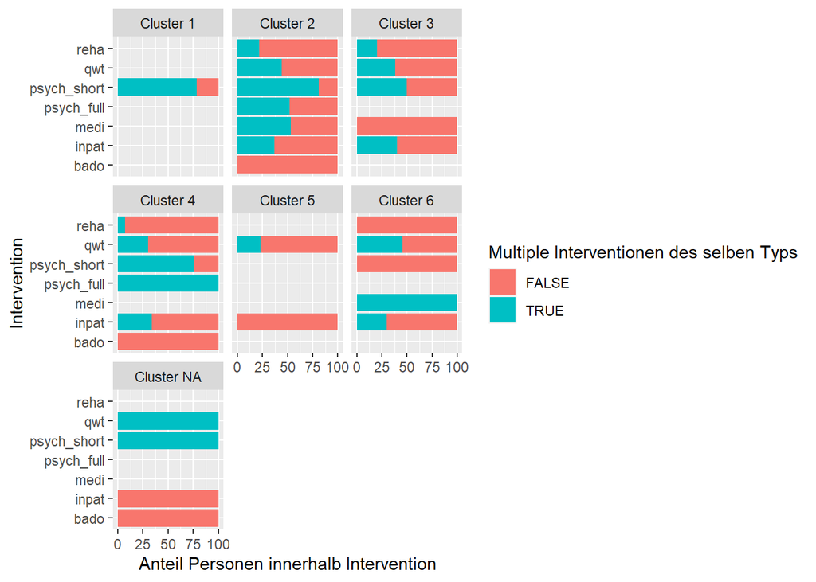

```r
#TODO: Explore mosaic plots{
#TODO: Zeitliche auflösung der zeitlichen Kreuztabellen durch Variablen ersetzen -
# TODO: Reha-qwt zusammenhang "Nicht fälle"! mit berücksichtigen als Spalte/Zeile
#TODO: Quarter Annahme raus nehmen und behandlungen durch tatsächliche interventions IDs ersetzen
#TODO: BLRT und Entropy berechnen!

dat_qwt_sum = dat_qwt_sum %>%
  left_join(dat_qwt_wide %>%
              select(pragmaid, cluster)) %>%
  rename(c(predclass = "cluster"))
dat_pred = dat_qwt_sum %>%
  select(pragmaid, predclass) %>%
  right_join(dat %>%
              filter(period == obs_period,
                     !is.na(interv_id_inner),
                     interv.any ==T)
             )
dat_pred %>%
  group_by(predclass) %>%
  mutate(n_class = n_distinct(pragmaid)) %>%
  ungroup() %>%
  group_by(pragmaid, predclass, interv.type) %>%
  mutate(num_intervs = n(), more_than_one_interv = num_intervs > 1) %>%
  group_by(predclass, interv.type) %>%
  mutate(n_had_interv = n_distinct(pragmaid)) %>%
  group_by(predclass, interv.type, more_than_one_interv) %>%
  summarize(n = n_distinct(pragmaid), frac = n/mean(n_had_interv)) %>%
  ggplot(aes(x = interv.type, y = frac * 100)) +
  geom_col(aes(fill = more_than_one_interv)) +
  facet_wrap(~paste("Cluster", predclass)) +
 # theme(axis.text.x = element_text(angle = 90, hjust = 1)) +
  labs(x = "Intervention", y = "Anteil Personen innerhalb Intervention", fill = "Multiple Interventionen des selben Typs") +
  coord_flip()
```

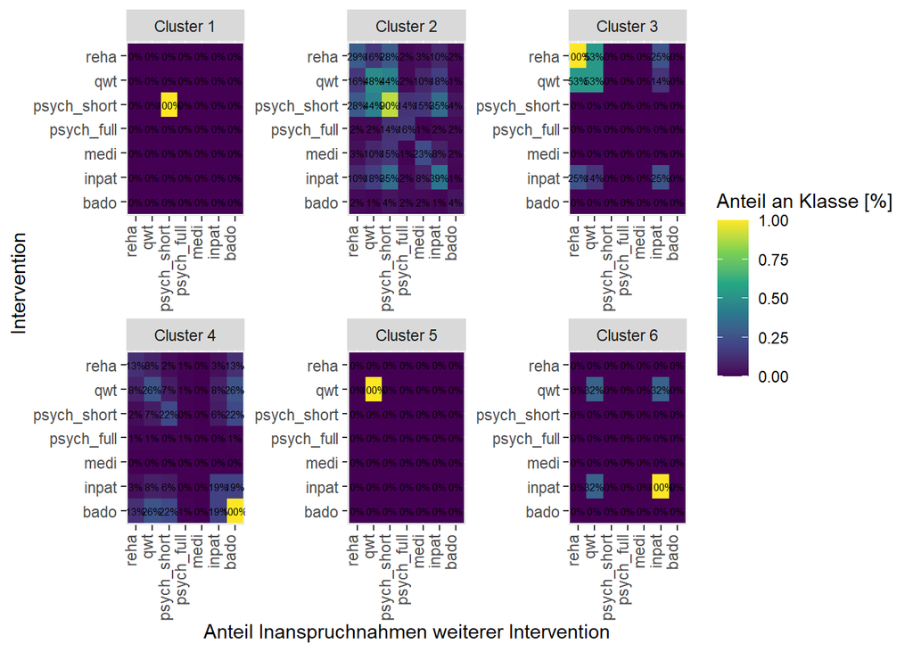

```r
dat_pred2 = dat_pred %>%
  select(pragmaid, predclass) %>%
  distinct() %>%
  right_join(dat_qwt %>%
  group_by(pragmaid) %>%
  summarize_at(analysis_vars, ~any(.x)))
# helper function
get_overlap = function(dat,
                       cls,
                       var1,
                       var2,
                       perspective = c("class", "intervention")){


  perspective = match.arg(perspective)
  if(perspective == "class"){
  overlaps = dat %>%
    ungroup() %>%
    filter(predclass == cls) %>%
    select(pragmaid, all_of(c(var1,var2))) %>%
    group_by(pragmaid) %>%
    summarize(overlap = all(pick(var1),  pick(var2)))
  }
  else{
    dat = dat[c(dat[var1] == TRUE), ]
    overlaps = dat %>%
    ungroup() %>%
    filter(predclass == cls) %>%
    select(pragmaid, all_of(c(var1,var2))) %>%
    group_by(pragmaid) %>%
    summarize(overlap = all(pick(var1),  pick(var2)))
  }

  overlap = sum(overlaps$overlap)/nrow(overlaps)

  # res = data.frame(var = var1, val = overlap)
  # names(res)[2] = var2
  return(overlap)
}
# helper function end


get_inter_variable_overlaps = function(dat,
                                       cls,
                                       analysis_vars,
                                       perspective =  c("class", "intervention")){

perspective = match.arg(perspective)


resresres = data.frame()
for(v1 in analysis_vars){
  resres = data.frame(var = v1)

  for(v2 in analysis_vars){
    res = data.frame(val = get_overlap(dat,
                                       cls,
                                       v1,
                                       v2,
                                       perspective = perspective))
    names(res) = v2
    resres = cbind(resres, res)
  }

  resresres = rbind(resresres, resres)
}
resresres$predclass = cls
return(resresres)
}





overlaps_class_persp = map_dfr(1:classnum,
                               ~ get_inter_variable_overlaps(
                                            dat_pred2,
                                            cls =.x,
                                            analysis_vars,
                                            perspective = "class"))


overlaps_interv_persp = map_dfr(1:classnum,
                                ~ get_inter_variable_overlaps(
                                            dat_pred2,
                                            cls =.x,
                                            analysis_vars,
                                            perspective = "intervention"))

overlaps_class_persp %>%
  pivot_longer(cols = all_of(analysis_vars),
               names_to = "var2",
               values_to = "val") %>%
  mutate(var = as.factor(var), var2 = as.factor(var2)) %>%
  ggplot(aes(x = reorder(var, desc(var)), y = var2, fill = val)) +
  geom_tile() +
  facet_wrap(~paste0("Cluster ", predclass), scales = "free") +
  geom_text(aes(label = paste0(round(val * 100, 0), "%")), size = 2) +
  scale_fill_viridis_c() +
  theme(axis.text.x = element_text(angle = 90, hjust = 1, vjust = 0)) +
  scale_x_discrete(limits = rev(levels(var))) +
  labs(x = "Anteil Inanspruchnahmen weiterer Intervention",
       y = "Intervention",
       fill = "Anteil an Klasse [%]")
```

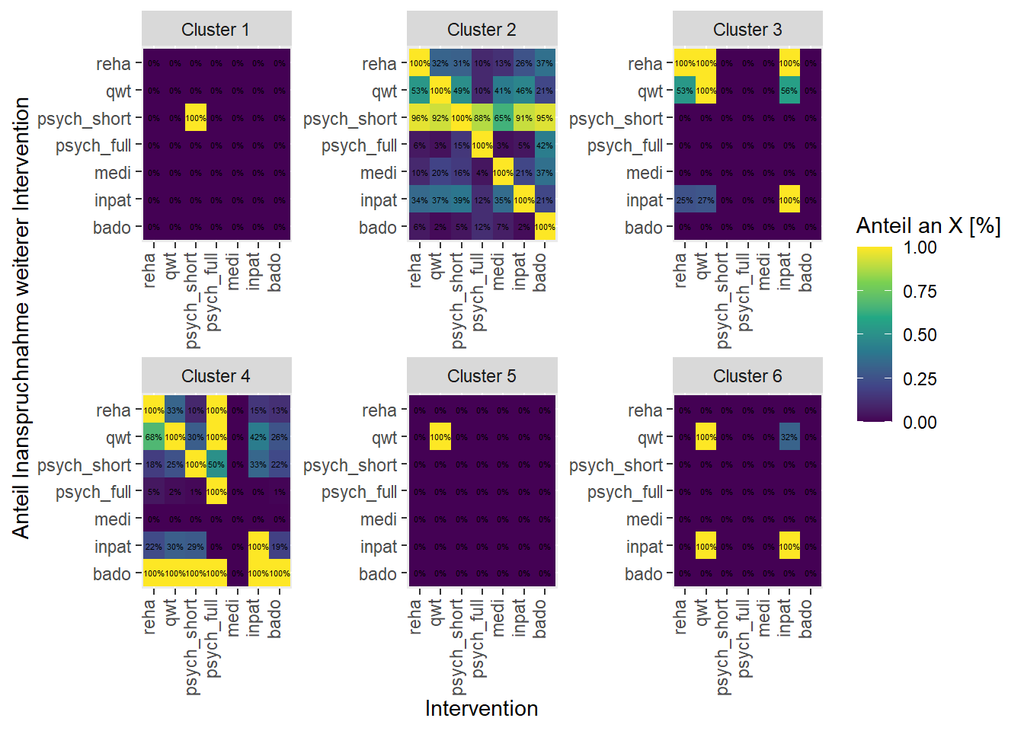

```r
overlaps_interv_persp %>%
  pivot_longer(cols = all_of(analysis_vars),
               names_to = "var2",
               values_to = "val") %>%
    mutate(var = as.factor(var), var2 = as.factor(var2),
           val = ifelse(is.nan(val), 0, val)) %>%
  ggplot(aes(x = reorder(var, desc(var)), y = var2, fill = val)) +
  geom_tile() +
  facet_wrap(~paste0("Cluster ", predclass), scales = "free") +
  geom_text(aes(label = paste0(round(val * 100, 0), "%")), size = 1.5) +
  scale_fill_viridis_c() +
  theme(axis.text.x = element_text(angle = 90, hjust = 1, vjust = 0)) +
  scale_x_discrete(limits = rev(levels(var))) +
  labs(x = "Intervention",
       y = "Anteil Inanspruchnahme weiterer Intervention",
       fill = "Anteil an X [%]")
```

Finally a Heatmap, basicly containing the same information as the plot above

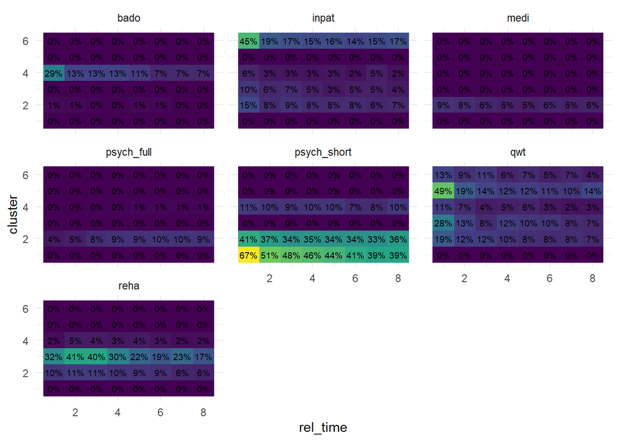

```r
# create a heatmap of the binary data used in the LCA
dat_qwt_wide %>%
  mutate(cluster = cuts) %>%
  select(pragmaid, cluster) %>%
  left_join(dat_qwt) %>%
  group_by(cluster, rel_time) %>%
  summarize_at(all_of(analysis_vars), ~ sum(.x)/length(.x), ) %>%
  pivot_longer(cols = all_of(analysis_vars),
               names_to = "variable",
               values_to = "value") %>%
  ggplot(aes(x = rel_time, y = cluster, fill = value)) +
  geom_tile(show.legend = F) +
  geom_text(aes(label = paste0(round(value, 2)*100,"%")), size = 2.5) +
  theme_minimal() +
  scale_fill_viridis_c() +
  facet_wrap(~variable)
```

## Conclusion

Overall, LCA and Hierarchical Clustering seem to identify similar groups. However, the LCA approach is more sophisticated and can be used to model the data generating process. The hierarchical clustering approach is more exploratory and can be used to identify groups in a more data driven way.

TODO:: Venn Diagramme updaten; Kreuztabelle zeitliche Personen Overlaps

Class probs all time resolutions